# Ten Simple Rules for Data Cleaning: A Tutorial with R and Tidyverse

# Overview

This script will go through the stages of loading and tidying 3 different data tables with variable kinds of data errors or biases that require noticing, sanity checking, and correcting or reorganizing. At the end, the participants table, variants table, and annotations table will be joined together and the dataset as a whole will be characterized and small analyses conducted.

The intention of this example walk through is:

1. To demonstrate some common data complexities, how to spot them, and how to fix them
2. To illustrate some useful data visualization tools
3. To demonstrate some common functions for manipulating data in a computational environment

# 1. Load in the messy data files provided in the repository.

## 1.1 Set up enviroment by loading the libraries (code packages) we need to run the scripts below

If you need to install these, you can do so with the install.packages() function, for example install.packages(“tidyverse”) to install the tidyverse package. You only need to do this once per computer, but you do need to load the library with library() each time you start a new R session and want to use the functions from that package.

Some packages require other installation instructions to get them from github or bioconductor rather than the standard CRAN repository. A google or LLM conversation should get you sorted with copy-paste instructions.

```r
#Environment set up, these libraries will be used to execute code
library(tidyverse)
library(DT)
library(janitor)
library(lubridate)
library(patchwork)
library(ggrepel)
library(skimr)
library(scales)
library(ggvenn)
library(broom)
conflicted::conflict_prefer("select", "dplyr")
conflicted::conflict_prefer("filter", "dplyr")
```

If you have downloaded the files to your computer, update the path below to point to the correct storage location.

## 1.2 Load all three tables into the R environment:

```r
raw_participants <- read_tsv("messy_participants.txt", show_col_types = TRUE)
raw_variants <- read_tsv("messy_variants.txt", show_col_types = TRUE)
raw_annotations <- read_csv("messy_annotations.csv", show_col_types = TRUE)
```

Tables can be viewed in the R or Positron environment by using the function View(df) or DT::datatable(df) which allows for interactive sorting and searching. If you are working in Positron, you can also take advantage of the file viewer sidebar to get a quick summary.

# 2. Participants Table

Begin with the Participants Table which contains meta-data, clinical data, and measurements for each of ten participants.

## 2.1 Viewing tables and getting familiar with the data

Two useful ways to start looking at the data are with either DT::datatable() or skim().

```r
# DT::datatable() allows you to interactively sort, filter, and search the table.
DT::datatable(raw_participants,
      filter = "top",
      options = list(pageLength = 5),
      rownames = FALSE)
```

| Participant ID | Age (years) | Sex, M/F | Phenotype | Leukocyte Count | Blood Pressure (mmHg) | Height | Weight | Date of Enrollment | Notes |
| --- | --- | --- | --- | --- | --- | --- | --- | --- | --- |
| P01 | 7 | Female | Intellectual disability; recurrent infections; delayed speech; microdontia; muscle weakness | 6.2 | 120/80 | 121cm | 68kg | 46022.5 | Consented at clinic visit. No known family history. |
| P02 | 29 | M | Cryptococcus infection\|Irritable Bowel Syndrome\|COVID-19 | 7.1 x10^9/L | 132/88 | 170cm | 82kg | 3/21/21 | Follow-up overdue; patient moved and changed GP. |
| P03 | 3 | female | Epilepsy | 5.9 | 118/76 | 88cm | 2kg | 5/2/21 |  |
| P04 |  | Male | Autoimmune lymphoproliferative syndrome due to CTLA4 haploinsufficiency; decreased total lymphocyte count; decreased circulating immunoglobulin; Eczematoid dermatitis; rash | 0.3 | 122/84 | 172cm | 55kg | 5/19/21 | DOB on file - calculate from records. |
| P05 | 32 | M | Intellectual disability | 999 | 140/90 | 155 cm | 58kg | 6/30/21 | 999 entered in error - sample not processed day of collection. |
| P06 | 38 | male | recurrent lower respiratory tract infections; bronchiectasis; situs inversus totalis | 6.8 | 128/82 | 186cm | 90kg | June 7 2021 | Spanish speaking patient. Interpreter present at consent. |
| P07 | 45 | Female | Obesity\|Global developmental delay | 7.2 | 130/85 | 168cm | 141.5lbs | 7/22/21 | Weight taken at GP surgery and recorded in lbs. Convert before analysis. |
| P08 | 55 | MALE | Heart failure, dyspnea, exertional fatigue | 6.1 | N/A | 178cm | 81kg | 8/9/21 | BP cuff unavailable at visit. Repeat measurement outstanding,see notes from cardiology |
| P09 | 27 | Male | healthy volunteer | 5.8 | 115/75 | 175cm | 79kg | 9/1/21 |  |
| P10 | 24 | male | Anxiety\|Depression\|Autism\|Attention-deficit Hyperactivity disorder | missing | 125/83 | 170cm | 73kg | 9/15/21 | CMA pending |

The skim() function gives you a nice summary of the data types, missingness, and distributions of values in each column.

```r
skim(raw_participants)
```

Data summary

| Name | raw_participants |
| --- | --- |
| Number of rows | 10 |
| Number of columns | 10 |
| _______________________ |  |
| Column type frequency: |  |
| character | 9 |
| numeric | 1 |
| ________________________ |  |
| Group variables | None |

**Variable type: character**

| skim_variable | n_missing | complete_rate | min | max | empty | n_unique | whitespace |
| --- | --- | --- | --- | --- | --- | --- | --- |
| Participant ID | 0 | 1.0 | 3 | 3 | 0 | 10 | 0 |
| Sex, M/F | 0 | 1.0 | 1 | 6 | 0 | 6 | 0 |
| Phenotype | 0 | 1.0 | 8 | 172 | 0 | 10 | 0 |
| Leukocyte Count | 0 | 1.0 | 3 | 11 | 0 | 10 | 0 |
| Blood Pressure (mmHg) | 0 | 1.0 | 3 | 6 | 0 | 10 | 0 |
| Height | 0 | 1.0 | 4 | 6 | 0 | 9 | 0 |
| Weight | 0 | 1.0 | 3 | 8 | 0 | 10 | 0 |
| Date of Enrollment | 0 | 1.0 | 6 | 11 | 0 | 10 | 0 |
| Notes | 2 | 0.8 | 11 | 86 | 0 | 8 | 0 |

**Variable type: numeric**

| skim_variable | n_missing | complete_rate | mean | sd | p0 | p25 | p50 | p75 | p100 | hist |
| --- | --- | --- | --- | --- | --- | --- | --- | --- | --- | --- |
| Age (years) | 1 | 0.9 | 28.89 | 16.62 | 3 | 24 | 29 | 38 | 55 | ▃▁▇▂▃ |

### 2.1.1 Delimiters and table structure

As an aside, the raw_participants table has been correctly read in as a tab-delimited .txt file and not comma-delimited .csv. If we had mistakenly read it in as a csv, the comma in the column name `Sex, M/F` would have incorrectly been used as a delimiter. We will not use this version, but see the mess below

```r
raw_participants_as_csv <- read_csv("messy_participants.txt", show_col_types = TRUE)
head(raw_participants_as_csv)
```

```
# A tibble: 6 × 2
  `Participant ID\tAge (years)\t"Sex`                     M/F"\tPhenotype\tLeu…¹
  <chr>                                                   <chr>
1 "P01\t7\tFemale\tIntellectual disability; recurrent in… <NA>
2 "P02\t29\tM\tCryptococcus infection|Irritable Bowel Sy… <NA>
3 "P03\t3\tfemale\tEpilepsy\t5.9\t118/76\t88cm\t2kg\t5/2… <NA>
4 "P04\tNA\tMale\tAutoimmune lymphoproliferative syndrom… <NA>
5 "P05\t32\tM\tIntellectual disability\t999\t140/90\t155… <NA>
6 "P06\t38\tmale\trecurrent lower respiratory tract infe… <NA>
# ℹ abbreviated name:
#   ¹`M/F"\tPhenotype\tLeukocyte Count\tBlood Pressure (mmHg)\tHeight\tWeight\tDate of Enrollment\tNotes`
```

## 2.2 Spotting and fixing data issues

Returning to the raw_participants table, we will want to notice and fix several issues.

1. The column names contain some special characters and units that will make them difficult to work with in R. We will want to clean these up.
2. The Leukocyte count column is being read as a string (characters) rather than numeric because the value 7.1 x10^9/L and the text word “missing” are not numbers. Values in this column should be coerced to numeric and “missing” represented as NA.
3. Similarly, blood pressure, height, weight, and date columns are being read as strings due to the presence of units and mixed formatting. You can not perform mathematical operations on these columns in their current state
4. The date column is inconsistently formatted and needs to be standardized if we want to use it as a date in any visualizations or analyses.
5. There is a missing value for participant P04’s age.
- If we review the free text “Notes” column, we can see that the investigator meant to fill that in from other sources but has not done so. This value should be added to the data sheet if it is available, or can be left as NA for truly missing.
- Do not fill a missing value with a placeholder like “unknown”, “missing”, or a dummy value.
6. There are values in Leukocyte count (“missing” and “999”) that *should be* represented as NA so that the code and downstream analysis recognizes these as missing values.

## 2.3 Begin cleaning

### 2.3.1 Changing column names

```r
participants <- raw_participants %>%
  clean_names()
```

For those new to R, renaming the object from `raw_participants` to `participants` is creating a new object in the R environment that contains the same data but with cleaned column names.

This is a common practice in data cleaning workflows to keep the original raw data separate and unmodified, while creating new objects as we process to analysis-ready versions. If we make a mistake in the cleaning process and drop or overwrite some values we want to recover we can always go back to the original raw data that we’d loaded.

**Important:** Columns, values, or any other edits done to an R object will not overwrite the actual raw `.csv` or `.txt` file on your computer – these objects only exist in your R environment. The raw files on your computer will remain unchanged unless/until you explicitly write over them with a function like `write_csv()` or `write_excel()`.

### 2.3.2 Age at enrollment

Start by plotting a histogram to see distribution of ages. Note that P04 is missing age data and will be excluded from this plot with a warning. But everything else looks as expected.

```
Warning: Removed 1 row containing non-finite outside the scale range
(`stat_bin()`).
```

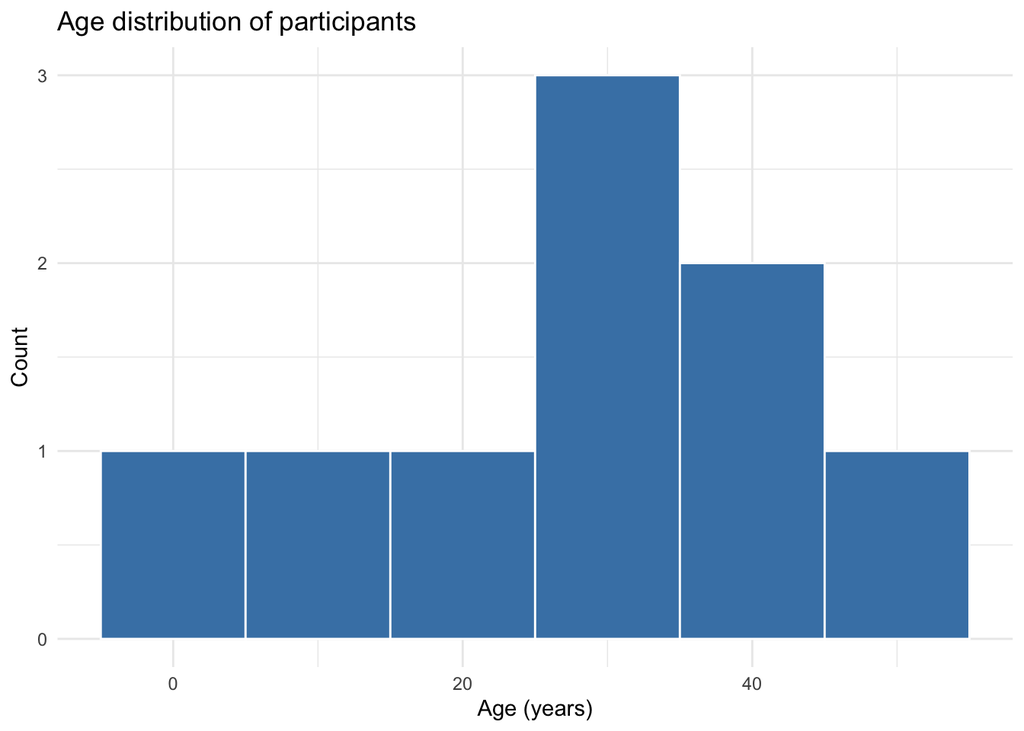

```r
ggplot(participants, aes(x = age_years)) +
  geom_histogram(binwidth = 10, fill = "steelblue", color = "white") +
  labs(title = "Age distribution of participants",
       x = "Age (years)", y = "Count") +
  theme_minimal()
```

### 2.3.3 Doing math with missing values

If we do a math function on without telling the code to ignore NA values we can get an NA result for the calculation.

This is intended to warn you - the user - that there are undefined values in that column and prevent a *silent* failure that could be misleading by requiring you to intentionally choose that you are OK to ignore missing.

```r
median(participants$age_years)
```

```
[1] NA
```

Adding the na.rm=TRUE argument tells the code you are comfortable ignoring the NA values, and the median should be calculated only on the available data.

```r
median(participants$age_years, na.rm = TRUE)
```

```
[1] 29
```

### 2.3.4 Sex and value standarization

Plot sex distribution using a bar chart scaled to fit the percentage of participants in each category up to 100%.

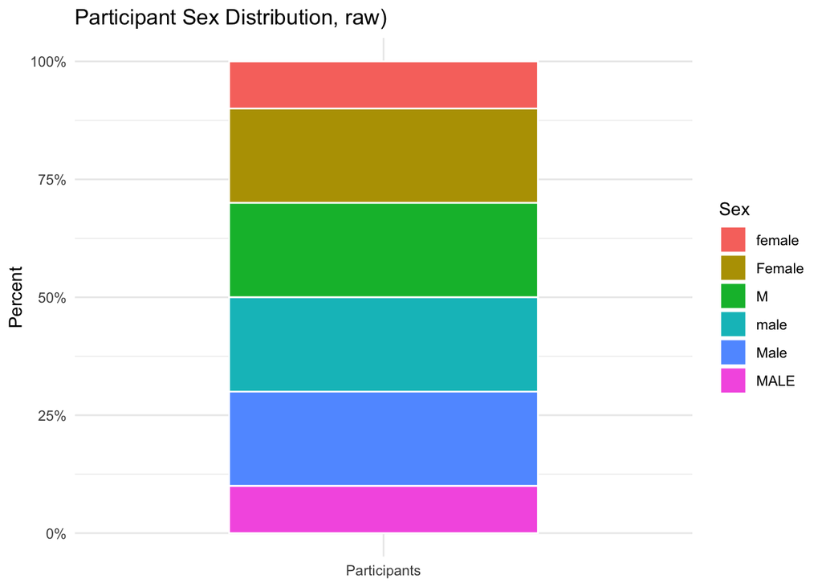

```r
participants %>%
  ggplot(aes(x = "Participants", fill = sex_m_f)) +
  geom_bar(position = "fill", width = 0.6, color = "white") +
  scale_y_continuous(labels = label_percent()) +
  labs(
    title = "Participant Sex Distribution, raw)",
    x = NULL,
    y = "Percent",
    fill = "Sex"
  ) +
  theme_minimal()
```

This reinforces that the code sees each different text string as a different category, despite the distinction between “M”, “Male”, and “MALE” being entirely meaningless and obviously identical to a human reader. We will want to standardize these values to a consistent text format.

There are many ways this can be done, but here we’ll use some stringr functions to recode the values by recognizing common patterns and setting all text to lowercase. Because we have no interest in preserving the original text values, we will overwrite the original column based on this formula. If we want to review the original values, we can look back at the raw_participants object which is unchanged.

```r
participants <- participants %>%
  mutate(sex_m_f = case_when(
    str_to_lower(sex_m_f) %in% c("f", "female") ~ "Female",
    str_to_lower(sex_m_f) %in% c("m", "male")   ~ "Male",
    TRUE ~ NA_character_
  ))
```

Plotting again, the data looks much better

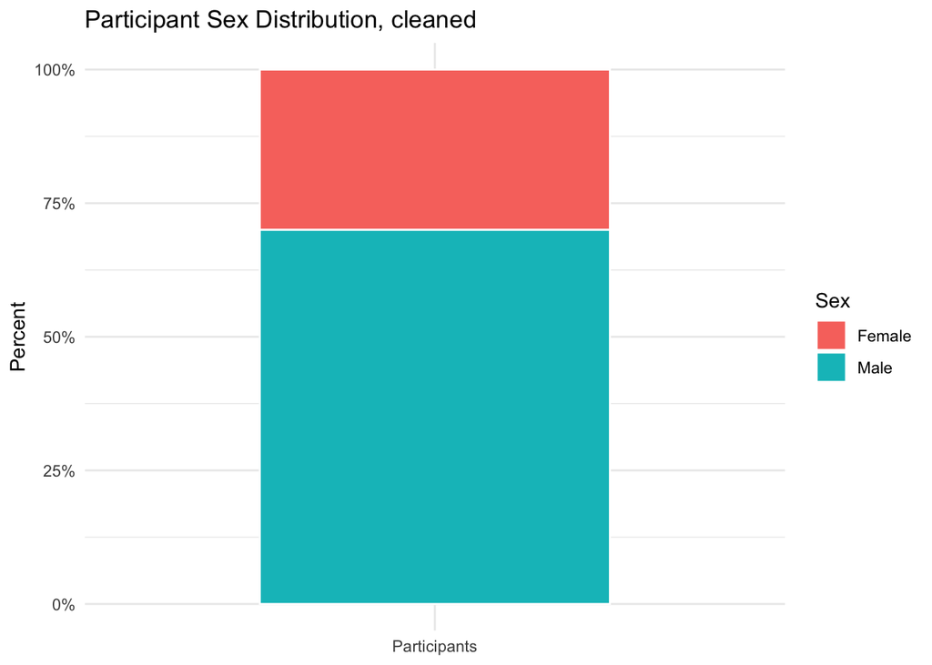

```r
participants %>%
  ggplot(aes(x = "Participants", fill = sex_m_f)) +
  geom_bar(position = "fill", width = 0.6, color = "white") +
  scale_y_continuous(labels = label_percent()) +
  labs(
    title = "Participant Sex Distribution, cleaned",
    x = NULL,
    y = "Percent",
    fill = "Sex"
  ) +
  theme_minimal()
```

### 2.3.5 Phenotypes and separating compound information into distinct variables

The phenotypes column is very complex. A few things to note when you look at it:

1. There is more than one thing described. Information about the affected status (healthy volunteer versus clinically described participants) and the clinical information itself are blended into the same column.
2. There may be a specific phenotype of interest that we want to use as a variable in the analysis. This new conceptual variable may be an umbrella term that covers more than one of the more detailed terms attributed to the participant. For example, if we want to compare participants with infections to those without, or count participants with documented evidence for intellectual disability.
3. There are multiple phenotypes listed in some cells, but they are delimited inconsistently with semicolons, pipes, and commas. If we simply want to use these as descriptive, we may be ok to leave those as they are. But if we want the code to recognize this as a list of multiple separate values rather than a single value of “phenotype1; phenotype2; phenotype3”, we will want to split these into multiple rows or convert the column to a list columns.

Create a new column “affected” that is derived from the phenotype column. In the formula below, if the phenotype contains the word “healthy”, then Affected == “Healthy”. If the phenotype contains any other value, then affected status is “Affected”.

```r
participants <- participants %>%
  mutate(affected = if_else(
    str_to_lower(phenotype) == "healthy volunteer", "Healthy", "Affected"
  ))

#We may then want to use logic to remove the "Healthy volunteer" from the phenotype column, while preserving the other phenotypes.
participants <- participants %>%
  mutate(phenotype = case_when(
    affected == "Healthy" ~ NA_character_,
    TRUE ~ phenotype
  ))
```

Next, we are interested in creating a variable (column) that flags any participants who have intellectual disability.

We will use our biomedical understanding to choose terms that we know are associated with this trait, and str_detect() which can look for partial matches, meaning we don’t need to split the phenotypes before running this code.

```r
participants <- participants %>%
  mutate(intellectual_disability = case_when(
    str_detect(str_to_lower(phenotype), "intellectual disability|developmental delay|intell|cognitive") ~ TRUE,
    .default = FALSE))
```

Count how many participants have intellectual disability according to this flag.

```r
participants %>%
  group_by(intellectual_disability) %>%
  summarize(n=n_distinct(participant_id))
```

```
# A tibble: 2 × 2
  intellectual_disability     n
  <lgl>                   <int>
1 FALSE                       7
2 TRUE                        3
```

### 2.3.6 Leukocyte Count, treating numbers as numbers, and standardizing missing values

We need to remove non-numeric scale characters from P02. We can also see that missing values are represented as both “missing” and “999” which need to be standardized to NA so that the code recognizes these properly as missing

```r
participants <- participants %>%
  mutate(leukocyte_count = str_remove(leukocyte_count, "\\s*x10\\^9/L"),
         leukocyte_count = na_if(leukocyte_count, "missing"),
         leukocyte_count = na_if(leukocyte_count, "999"),
         leukocyte_count = as.numeric(leukocyte_count))
```

Look at the data as a distribution of leukocyte counts across the cohort

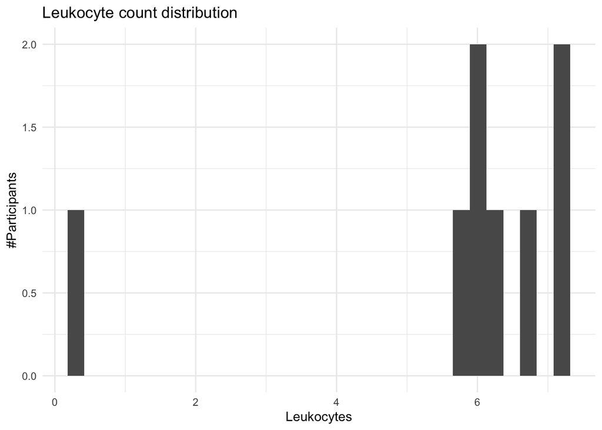

```r
ggplot(participants, aes(x = leukocyte_count)) +
  geom_histogram() +
  labs(title = "Leukocyte count distribution",
       x = "Leukocytes", y = "#Participants") +
  theme_minimal()
```

Look at the data as a value for each particpant. We can see that values largely lie within the normal range with two missing participants and a severe outlier in P04. Reviewing, this expected for this individual.

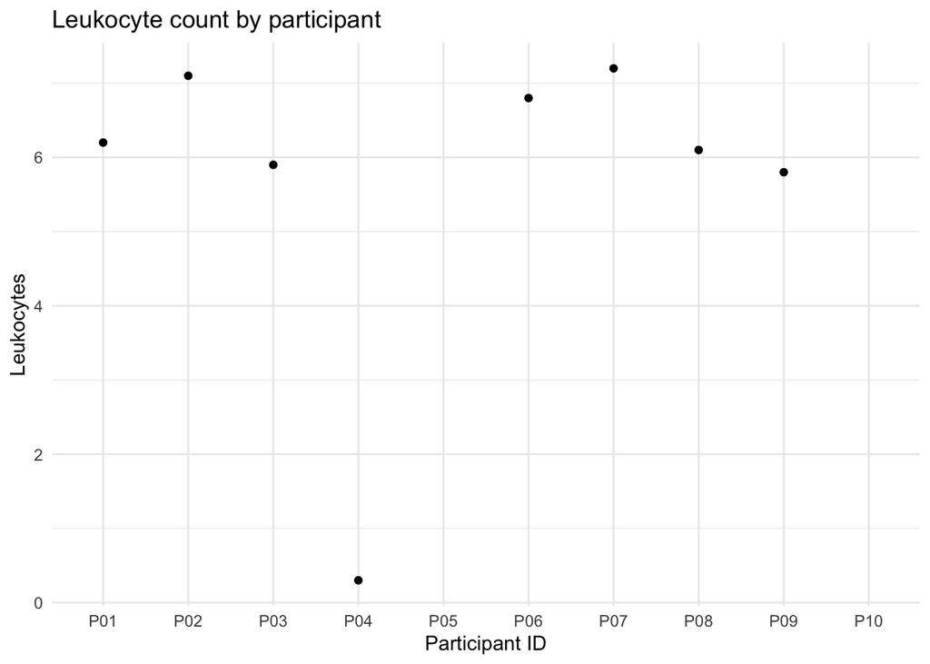

```r
ggplot(participants, aes(x = participant_id, y = leukocyte_count)) +
  geom_point() +
  labs(title = "Leukocyte count by participant",
       x = "Participant ID", y = "Leukocytes") +
  theme_minimal()
```

### 2.3.7 Blood Pressure and splitting based on a delimiter

Blood pressure here is being read as a string because of the `/` character that is splitting the systolic and diastolic values. We will want to split this into two separate columns for systolic and diastolic blood pressure and convert those to numeric.

```r
participants <- participants %>%
  separate_wider_delim(
    cols = blood_pressure_mm_hg,
    delim = "/",
    names = c("bp_systolic", "bp_diastolic")
  )
```

The N/A value in P08 actually splits as well, into “N” and “A”. We want to get rid of this.

If you did not expect any non-numeric values in the column, this warning should make you look back at the data and make sure you have not introduced errors or dropped data.

```r
participants <- participants %>%
  mutate(bp_systolic = as.numeric(bp_systolic),
         bp_diastolic = as.numeric(bp_diastolic))
```

```
Warning: There were 2 warnings in `mutate()`.
The first warning was:
ℹ In argument: `bp_systolic = as.numeric(bp_systolic)`.
Caused by warning:
! NAs introduced by coercion
ℹ Run `dplyr::last_dplyr_warnings()` to see the 1 remaining warning.
```

### 2.3.8 Height and checking outliers

As in previous examples, we want to remove the units from this cell and have these recognized as numbers

```r
participants <- participants %>%
  mutate(height_cm = as.numeric(str_remove(height, "\\s*cm"))) %>%
  select(-height)
```

Plot and look at the distribution. We see a clear outlier and want to review that for plausibility (sanity check).

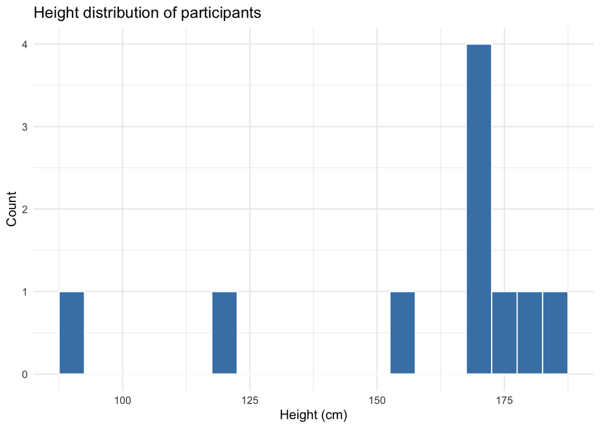

```r
participants %>%
  ggplot(aes(x = height_cm)) +
  geom_histogram(binwidth = 5, fill = "steelblue", color = "white") +
  labs(title = "Height distribution of participants",
       x = "Height (cm)", y = "Count") +
  theme_minimal()
```

We can use the table to find out who has a height less than 100cm. Here, we see that individual P03 who is only 3years old is our outlier, and that height is not suspicious for a child. Thus the short stature is plausible, and will be retained.

With only 10 participants, we could have just looked at the table, but filtering functioons allow this type of question to scale effectively.

```r
participants %>%
  filter(height_cm < 100) %>%
  dplyr::select(participant_id, age_years, height_cm)
```

```
# A tibble: 1 × 3
  participant_id age_years height_cm
  <chr>              <dbl>     <dbl>
1 P03                    3        88
```

### 2.3.9 Weight and correcting a single value

There are several data entry errors embedded in this column.

Lets try to evaluate the range first, before cleaning. What we actually see is an alphabetic/alphanumeric sorting where starts with 1 is the minimum and starts with 9 is the maximum. This is not what we’d wanted to see.

```r
min(participants$weight)
```

```
[1] "141.5lbs"
```

```r
max(participants$weight)
```

```
[1] "90kg"
```

Processing the data more, let’s split the units from the numeric values first rather than just dropping them as we’d done before. We’ll send all numbers to the value “weight_num” and all letters to the column “unit” and take a look.

```r
participants <- participants %>%
  mutate(
    weight_num = parse_number(weight),
    unit = str_extract(weight, "[[:alpha:]]+") %>% str_to_lower()
  )
```

Two clear things need addressing. First, we have mixed units (lb and kg) that need to be reviewed and standardized. Second, we have a clear outlier with weight of 2kg which needs to be investigated as a possible data entry error.

```r
participants %>%
  dplyr::select(weight, weight_num, unit) %>%
  arrange(desc(weight_num))
```

```
# A tibble: 10 × 3
   weight   weight_num unit
   <chr>         <dbl> <chr>
 1 141.5lbs       142. lbs
 2 90kg            90  kg
 3 82kg            82  kg
 4 81kg            81  kg
 5 79kg            79  kg
 6 73kg            73  kg
 7 68kg            68  kg
 8 58kg            58  kg
 9 55kg            55  kg
10 2kg              2  kg
```

After we review source notes and are confident that the “lbs” value is truly recorded in pounds and needs conversion (vs a typo when writing units into the table), we can mathematically do that here.

```r
participants<-participants %>%
  mutate(weight_kg = case_when(
    unit == "lbs" ~ weight_num / 2.205,
    TRUE ~ weight_num
  ))

# Check our conversion success
participants %>%
  dplyr::select(participant_id, weight, weight_num, unit, weight_kg) %>%
  arrange(desc(weight_kg))
```

```
# A tibble: 10 × 5
   participant_id weight   weight_num unit  weight_kg
   <chr>          <chr>         <dbl> <chr>     <dbl>
 1 P06            90kg            90  kg         90
 2 P02            82kg            82  kg         82
 3 P08            81kg            81  kg         81
 4 P09            79kg            79  kg         79
 5 P10            73kg            73  kg         73
 6 P01            68kg            68  kg         68
 7 P07            141.5lbs       142. lbs        64.2
 8 P05            58kg            58  kg         58
 9 P04            55kg            55  kg         55
10 P03            2kg              2  kg          2
```

```r
# Now drop the other columns to avoid future confusion, keeping only the weight in kg as a cleaned variable for future analysis.
participants <- participants %>%
  select(-weight, -weight_num, -unit)
```

Plot the distribution of weight in kg.

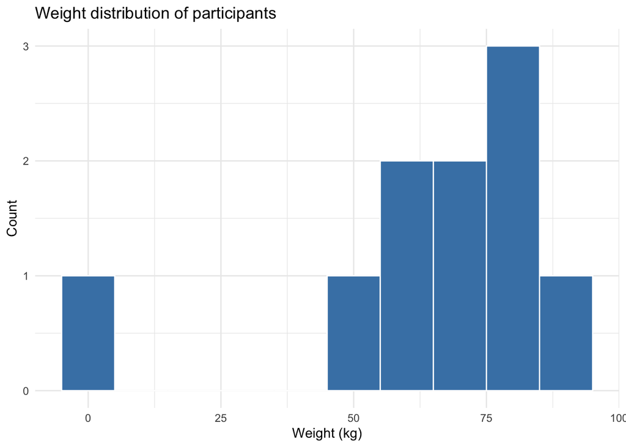

```r
participants %>%
  ggplot(aes(x = weight_kg)) +
  geom_histogram(binwidth = 10, fill = "steelblue", color = "white") +
  labs(title = "Weight distribution of participants",
       x = "Weight (kg)", y = "Count") +
  theme_minimal()
```

The participant with recorded weight of 2kg is is clearly a data entry error, even for a 3yr old.

If possible, we will want to return to any original source notes to see if the value can be corrected to a true value, but barring that, we will want to blank it out as missing rather than allowing the error to enter our analysis. In this example, the true value is found in notes as 24kg. This can be corrected on the original data sheet, but we’ll demonstrate how to do it here as well.

```r
# For any weight value less than 5kg, replace with 24kg. We could also be exact and use for weight_kg == 2 then 24.
participants <- participants %>%
  mutate(weight_kg = case_when(
    weight_kg < 5 ~ 24, # based on review of notes
    .default = weight_kg
  ))
```

Plot the corrected distribution

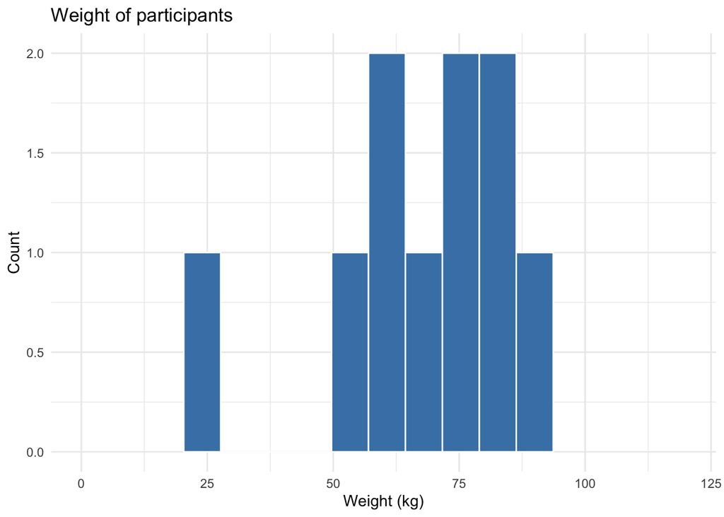

```r
participants %>%
  ggplot(aes(x = weight_kg)) +
  geom_histogram(bins = 10, fill = "steelblue", color = "white") +
  coord_cartesian(xlim = c(0, 120)) +
  labs(title = "Weight of participants",
       x = "Weight (kg)", y = "Count") +
  theme_minimal()
```

### 2.3.10 Dates

The recorded dates appear to be entered pretty freely and inconsistently. We even have a date that appears to have been auto-converted to an Excel serial number.

```r
unique(participants$date_of_enrollment)
```

```
 [1] "46022.5"     "3/21/21"     "5/2/21"      "5/19/21"     "6/30/21"
 [6] "June 7 2021" "7/22/21"     "8/9/21"      "9/1/21"      "9/15/21"
```

LLMs can create a variety of custom scripts capable of parsing dates, relying on the janitor::convert_to_date or lubridate::parse_date_time functions which are designed to recognize dates specifically and standardize their representations.

```r
# This is a complex custom function, but if you're working with an LLM code assistant - you don't need to write it, you just need to review the input and output as matching, and make sure the LLM is accurately parsing all the variety properly. While you can overwrite the column, here we'll create a second column (date_of_enrollment_std) that allows manual comparison with the input.
participants <- participants %>%
  mutate(
    date_of_enrollment_std = janitor::convert_to_date(
      date_of_enrollment,
      character_fun = \(x) {
        x <- stringr::str_squish(x)

        is_excel_num <- stringr::str_detect(x, "^\\d+(\\.\\d+)?$")

        out <- rep(as.Date(NA), length(x))

        # Excel serial date (origin handles Excel's date system)
        out[is_excel_num] <- as.Date(as.numeric(x[is_excel_num]), origin = "1899-12-30")

        # Character dates like 3/14/21 or June 7 2021
        out[!is_excel_num] <- lubridate::parse_date_time(
          x[!is_excel_num],
          orders = c("mdy", "B d Y", "b d Y")
        ) |>
          as.Date()

        out
      }
    )
  )
```

Check that the function has accurately standardized the dates.

```r
participants %>%
  select(participant_id, date_of_enrollment, date_of_enrollment_std)
```

```
# A tibble: 10 × 3
   participant_id date_of_enrollment date_of_enrollment_std
   <chr>          <chr>              <date>
 1 P01            46022.5            2025-12-31
 2 P02            3/21/21            2021-03-21
 3 P03            5/2/21             2021-05-02
 4 P04            5/19/21            2021-05-19
 5 P05            6/30/21            2021-06-30
 6 P06            June 7 2021        2021-06-07
 7 P07            7/22/21            2021-07-22
 8 P08            8/9/21             2021-08-09
 9 P09            9/1/21             2021-09-01
10 P10            9/15/21            2021-09-15
```

### 2.3.11 Reorganize your table

To improve human readability and scanability, reorder some columns. A relocate() function could also be used here.

```r
participants <- participants %>%
  select(participant_id, affected, date_of_enrollment_std, age_years, sex_m_f, height_cm, weight_kg, everything())
```

### 2.3.12 Admire your work

Notice which columns are now properly represented as numeric or dates, check the missing fraction as expected, see minimums, maximums, completion rate summaries, etc. You’re ready to go.

```r
skim(participants)
```

Data summary

| Name | participants |
| --- | --- |
| Number of rows | 10 |
| Number of columns | 14 |
| _______________________ |  |
| Column type frequency: |  |
| character | 6 |
| Date | 1 |
| logical | 1 |
| numeric | 6 |
| ________________________ |  |
| Group variables | None |

**Variable type: character**

| skim_variable | n_missing | complete_rate | min | max | empty | n_unique | whitespace |
| --- | --- | --- | --- | --- | --- | --- | --- |
| participant_id | 0 | 1.0 | 3 | 3 | 0 | 10 | 0 |
| affected | 0 | 1.0 | 7 | 8 | 0 | 2 | 0 |
| sex_m_f | 0 | 1.0 | 4 | 6 | 0 | 2 | 0 |
| phenotype | 1 | 0.9 | 8 | 172 | 0 | 9 | 0 |
| date_of_enrollment | 0 | 1.0 | 6 | 11 | 0 | 10 | 0 |
| notes | 2 | 0.8 | 11 | 86 | 0 | 8 | 0 |

**Variable type: Date**

| skim_variable | n_missing | complete_rate | min | max | median | n_unique |
| --- | --- | --- | --- | --- | --- | --- |
| date_of_enrollment_std | 0 | 1 | 2021-03-21 | 2025-12-31 | 2021-07-11 | 10 |

**Variable type: logical**

| skim_variable | n_missing | complete_rate | mean | count |
| --- | --- | --- | --- | --- |
| intellectual_disability | 0 | 1 | 0.3 | FAL: 7, TRU: 3 |

**Variable type: numeric**

| skim_variable | n_missing | complete_rate | mean | sd | p0 | p25 | p50 | p75 | p100 | hist |
| --- | --- | --- | --- | --- | --- | --- | --- | --- | --- | --- |
| age_years | 1 | 0.9 | 28.89 | 16.62 | 3.0 | 24.00 | 29.00 | 38.00 | 55.0 | ▃▁▇▂▃ |
| height_cm | 0 | 1.0 | 158.30 | 30.43 | 88.0 | 158.25 | 170.00 | 174.25 | 186.0 | ▁▁▁▁▇ |
| weight_kg | 0 | 1.0 | 67.42 | 18.89 | 24.0 | 59.54 | 70.50 | 80.50 | 90.0 | ▂▁▃▆▇ |
| leukocyte_count | 2 | 0.8 | 5.68 | 2.24 | 0.3 | 5.88 | 6.15 | 6.88 | 7.2 | ▁▁▁▁▇ |
| bp_systolic | 1 | 0.9 | 125.56 | 7.81 | 115.0 | 120.00 | 125.00 | 130.00 | 140.0 | ▇▅▅▂▂ |
| bp_diastolic | 1 | 0.9 | 82.56 | 5.00 | 75.0 | 80.00 | 83.00 | 85.00 | 90.0 | ▅▂▇▂▅ |

# 3. Variants Table

```r
head(raw_variants)
```

```
# A tibble: 6 × 6
  Participant Gene_Zygosity Genomic_Position (chr-pos-ref…¹ `HGVS (HGVSc/HGVSp)`
  <chr>       <chr>         <chr>                           <chr>
1 P01         ARID1B (het)  chr6-157174117-G-A              c.3345G>A / p.Lys11…
2 P01         ARID1B (het)  chr6-157206564-G-A              c.5792G>A / p.Arg19…
3 P01         G6PD (hom)    chrX-154532247-G-A              c.1398C>T / p.Thr46…
4 P01         SCN1A (het)   chr2-166053034-C-T              c.603-91G>A
5 P02         CCR7_het      chr17-40554783-T-C              c.1096A>G / p.Met36…
6 P03         SCN1A (het)   chr2-166043878-G-A              c.5566G>A / p.Gly18…
# ℹ abbreviated name: ¹`Genomic_Position (chr-pos-ref-alt)`
# ℹ 2 more variables: Variant_Type <chr>, Phenotype_Association <chr>
```

Plenty of data cleanup required here too. As we walked through it before, we’ll combine several steps in our first pass.

## 3.1 Genomic coordinates and non-ambiguous data

This longer script chains together a series of operations similar to what was done stepwise above. The goal is to have genomic coordinates as both an ID (chr-pos-ref-alt), and as manipulable values.

```r
variants<-raw_variants %>%
  clean_names() %>%

# create a duplicate of the genomic coordinates column so we can work with it as an ID (chr-pos-ref-alt) and/or as chromosomal and numeric positional data.
  mutate(genomic_position = genomic_position_chr_pos_ref_alt) %>%

# split one of the duplicates into chrom, pos, ref and alt columns
  separate(
    genomic_position_chr_pos_ref_alt,
    into = c("chrom", "pos", "ref", "alt"),
    sep = "-",
    extra = "merge"
  ) %>%

# Convert the position column to numeric
  mutate(pos = as.integer(pos)) %>%

# Convert variant type to title case for standardization and readability
  mutate(variant_type = str_to_title(variant_type)) %>%

# Separate the hgvsc and hgvsp to individual columns based on the / delimiter.
  separate(
    hgvs_hgv_sc_hgv_sp,
    into = c("hgvsc", "hgvsp"),
    sep = "\\s*/\\s*"
  ) %>%

# The simple separation leaves some leading and trailing whitespaces. We want to get rid of those as code treats them as characters that are part of the value. The str_trim() function is designed to do just that.
# In addition, variants affecting non-coding sequences seem to have hgvsp represented with a dot "." to represent not applicable. We would like to convert that to NA, and so if trimming the leading and trailing spaces leaves us with just a dot - na_if() does this for us.
  mutate(hgvsp = na_if(str_trim(hgvsp), "."))
```

Visualize the variant data with a bar graph that counts variants/chromosome and colors by variant type.

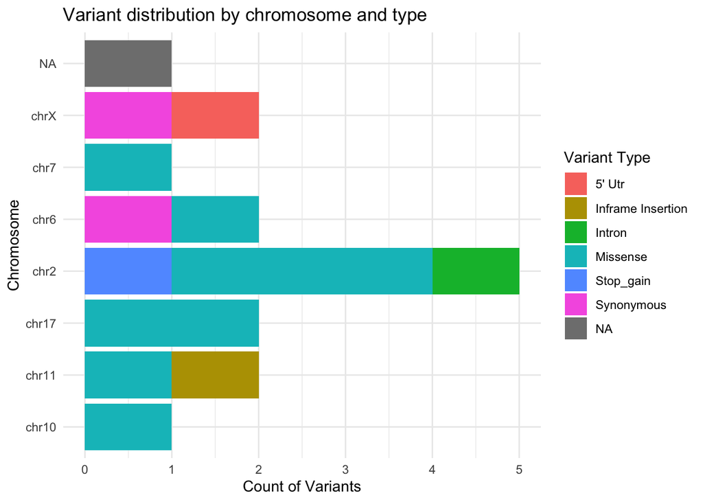

```r
ggplot(variants, aes(x = chrom, fill = variant_type)) +
  geom_bar(position = "stack") +
  labs(title = "Variant distribution by chromosome and type",
       x = "Chromosome", y = "Count of Variants", fill = "Variant Type") +
  theme_minimal() +
  coord_flip()
```

After running the function above, we want to evaluate its completeness by printing all the rows where hgvsp or chr is blank/missing. Had we left “.” behind, we would have to remember to include that in our filter as well, as a “.” is not a missing value to a computer.

```r
variants %>%
  filter(is.na(hgvsp) | is.na(chrom))  %>%
  dplyr::select(gene_zygosity, variant_type, hgvsc, hgvsp, chrom, pos)
```

```
# A tibble: 3 × 6
  gene_zygosity variant_type hgvsc       hgvsp chrom       pos
  <chr>         <chr>        <chr>       <chr> <chr>     <int>
1 SCN1A (het)   Intron       c.603-91G>A <NA>  chr2  166053034
2 trisomy 21    <NA>         <NA>        <NA>  <NA>         NA
3 MECP-2        5' Utr       c.-46_-45de <NA>  chrX  154097709
```

Above, we could see that there are three variant rows returned.

Two of these are expected as the variant lands in an non-coding region and thus does not have a protein coding change (hgvsp). The third reveals a more complex situation as this participant has an extra copy of chromosome 21 (information we want); however the gene and variant information about that is not being well-represented in the table. We need to make a decision about how we want to capture it.

## 3.2 Manually changing table data

Sometimes, you may need/want to fill missing data into your working table or change the representation of data that’s present your table in a targeted way based on the way you want to work with the data in the moment. You do not *have* to always return to Excel, etc to re-type.

**Decision:** for the trisomy21 variant, enter variant type as “chromosome_duplication”, leave hgvsc and hgvsp blank, and document the chrom, pos, ref, and alt in a custom fashion with “N” (for normal) and “CN3” (for copy number 3) as ref/alt configuration.

- These particular choices are entirely arbitrary for this purpose and do not reflect best practices in genomics for representation of copy number variants.

Representing these bits of information more comprehensively allows the trisomy 21 variant to be counted or plotted as non-blank when we work with these columns.

```r
# Participants with at least one variant in the table.
# The function n_distinct() does count NA as a unique value even though that may not be intuitive behaviour to an analyst, so we want to use sum(!is.na(genomic_position)) to count only non-missing variants.
variants %>%
  group_by(participant) %>%
  summarize(n_variants = sum(!is.na(genomic_position)))
```

```
# A tibble: 9 × 2
  participant n_variants
  <chr>            <int>
1 P01                  4
2 P02                  1
3 P03                  2
4 P04                  2
5 P06                  2
6 P07                  1
7 P08                  1
8 P09                  1
9 P10                  1
```

Fill in the custom information we decided above for documenting trisomy into this table using case_when() to modify the intended value *when* some other value in the row is true.

```r
variants<-variants %>%
  mutate(
    variant_type = case_when(
      str_detect(gene_zygosity, "trisomy 21") ~ "chromosome_duplication",
      TRUE ~ variant_type
    ),
    chrom = case_when(
      str_detect(gene_zygosity, "trisomy 21") ~ "chr21",
      TRUE ~ chrom
    ),
    ref = case_when(
      str_detect(gene_zygosity, "trisomy 21") ~ "N",
      TRUE ~ ref
    ),
    alt = case_when(
      str_detect(gene_zygosity, "trisomy 21") ~ "CN3",
      TRUE ~ alt
    ),
    genomic_position = case_when(
      str_detect(gene_zygosity, "trisomy 21") ~ "chr21-CN3",
      TRUE ~ genomic_position
    )
  )
```

We can now see that participant P07 has two distinct, non-NA variants accounted for. Just what we wanted.

```r
variants %>%
  group_by(participant) %>%
  summarize(n_variants = sum(!is.na(genomic_position)))
```

```
# A tibble: 9 × 2
  participant n_variants
  <chr>            <int>
1 P01                  4
2 P02                  1
3 P03                  2
4 P04                  2
5 P06                  2
6 P07                  2
7 P08                  1
8 P09                  1
9 P10                  1
```

## 3.3 Gene and zygosity column and extracting mixed information from complex columns

The gene and zygosity information is blended in one column and the way it is recorded doesn’t have an easy delimiter value to split by. After taking a look at the table, we see we need to do a few operations here to separate those concepts into their own columns and standardize the value representations.

```r
variants <- variants %>%

# Strip off leading and trailing whitespace
  mutate(
    gene_zygosity = str_squish(gene_zygosity),

# Since we noticed the unnecessary dash in MECP2 (not part of the formal gene name per HGNC nomenclature), let's remove that too. This script replaces every "-" with nothing instead "". More complex functions would be possible but are not necessary in this dataset
    gene_zygosity = str_replace_all(gene_zygosity, regex("-", ignore_case = TRUE), ""),

# We will try to extract gene names from their current representation by taking the leading alphanumeric characters before the first space or parenthesis, and converting to uppercase for standardization.
   gene = gene_zygosity %>%
      str_extract("^[A-Za-z0-9]+") %>%
      str_to_upper(),

#Zygosity will be captured by detecting strings that match hemi, hom, or het patterns, ignoring case. Because we bring the external knowledge that germline PTEN as a secondary finding must be heterozyous, we'll match that into the pattern, though it is best practice to review the raw data.
    zygosity = case_when(
      str_detect(gene_zygosity, "hem") ~ "Hemizygous",
      str_detect(gene_zygosity, "hom") ~ "Homozygous",
      str_detect(gene_zygosity, "het|secondary") ~ "Heterozygous",
      .default = NA_character_
      )
    )
```

See how we did?

```r
variants %>%
  select(gene_zygosity, gene, zygosity) %>%
  arrange(gene)
```

```
# A tibble: 16 × 3
   gene_zygosity          gene    zygosity
   <chr>                  <chr>   <chr>
 1 ARID1B (het)           ARID1B  Heterozygous
 2 ARID1B (het)           ARID1B  Heterozygous
 3 BRCA1_heterozygous     BRCA1   Heterozygous
 4 CCR7_het               CCR7    Heterozygous
 5 CFTR (het)             CFTR    Heterozygous
 6 CTLA4 (het)            CTLA4   Heterozygous
 7 DNAH7 (het             DNAH7   Heterozygous
 8 DNAH7                  DNAH7   <NA>
 9 G6PD (hom)             G6PD    Homozygous
10 HBB (het)              HBB     Heterozygous
11 MECP2                  MECP2   <NA>
12 MYBPC3 (het)           MYBPC3  Heterozygous
13 PTEN secondary finding PTEN    Heterozygous
14 SCN1A (het)            SCN1A   Heterozygous
15 SCN1A (het)            SCN1A   Heterozygous
16 trisomy 21             TRISOMY <NA>
```

Since we know that the information on gene zygosity must exist for all the variants, missing simply because it was not recorded. So this calls for returning to source documents to fill in the missing information accurately. We will assume source documentation reveals that the two short variants with missing zygosity are actually heterozygous.

```r
variants <- variants %>%
  mutate(zygosity = case_when(
    gene == "TRISOMY" ~ "CN3",
    is.na(zygosity) ~ "Heterozygous",
    TRUE ~ zygosity
  ))

variants %>%
  select(gene_zygosity, gene, zygosity) %>%
  arrange(gene)
```

```
# A tibble: 16 × 3
   gene_zygosity          gene    zygosity
   <chr>                  <chr>   <chr>
 1 ARID1B (het)           ARID1B  Heterozygous
 2 ARID1B (het)           ARID1B  Heterozygous
 3 BRCA1_heterozygous     BRCA1   Heterozygous
 4 CCR7_het               CCR7    Heterozygous
 5 CFTR (het)             CFTR    Heterozygous
 6 CTLA4 (het)            CTLA4   Heterozygous
 7 DNAH7 (het             DNAH7   Heterozygous
 8 DNAH7                  DNAH7   Heterozygous
 9 G6PD (hom)             G6PD    Homozygous
10 HBB (het)              HBB     Heterozygous
11 MECP2                  MECP2   Heterozygous
12 MYBPC3 (het)           MYBPC3  Heterozygous
13 PTEN secondary finding PTEN    Heterozygous
14 SCN1A (het)            SCN1A   Heterozygous
15 SCN1A (het)            SCN1A   Heterozygous
16 trisomy 21             TRISOMY CN3
```

```r
# Drop the blended gene_zygosity column now that we have extracted the information we wanted from it into separate columns. It can be retained, but it will not be used again
variants <- variants %>%
  select(-gene_zygosity)
```

## 3.4 Now we look at the data to get familiar with it

How many unique variants do we have?

```r
n_distinct(variants$genomic_position)
```

```
[1] 16
```

How many participants are in this table with at least one variant described?

```r
n_distinct(variants$participant)
```

```
[1] 9
```

What types of variants are present in this table?

```r
count(variants, variant_type)
```

```
# A tibble: 7 × 2
  variant_type               n
  <chr>                  <int>
1 5' Utr                     1
2 Inframe Insertion          1
3 Intron                     1
4 Missense                   9
5 Stop_gain                  1
6 Synonymous                 2
7 chromosome_duplication     1
```

Which genes are present with annotated variants, and what kinds? Who carries them?

```r
variants %>%
  group_by(gene) %>%
  summarize(
    nVariants=n_distinct(genomic_position),
    nParticipants=n_distinct(participant),
    variant_types = paste(unique(variant_type), collapse = "; "),
    carriers = paste(unique(participant), collapse = "; ")
  ) %>%
  arrange(desc(nParticipants))
```

```
# A tibble: 13 × 5
   gene    nVariants nParticipants variant_types          carriers
   <chr>       <int>         <int> <chr>                  <chr>
 1 SCN1A           2             2 Intron; Stop_gain      P01; P03
 2 ARID1B          2             1 Synonymous; Missense   P01
 3 BRCA1           1             1 Missense               P07
 4 CCR7            1             1 Missense               P02
 5 CFTR            1             1 Missense               P04
 6 CTLA4           1             1 Missense               P04
 7 DNAH7           2             1 Missense               P06
 8 G6PD            1             1 Synonymous             P01
 9 HBB             1             1 Missense               P09
10 MECP2           1             1 5' Utr                 P10
11 MYBPC3          1             1 Inframe Insertion      P08
12 PTEN            1             1 Missense               P03
13 TRISOMY         1             1 chromosome_duplication P07
```

# 4. Annotations Table.

Quick look at the annotations table from file

```r
skim(raw_annotations)
```

Data summary

| Name | raw_annotations |
| --- | --- |
| Number of rows | 16 |
| Number of columns | 7 |
| _______________________ |  |
| Column type frequency: |  |
| character | 7 |
| ________________________ |  |
| Group variables | None |

**Variable type: character**

| skim_variable | n_missing | complete_rate | min | max | empty | n_unique | whitespace |
| --- | --- | --- | --- | --- | --- | --- | --- |
| Genomic_Position (chr-pos-ref-alt) | 0 | 1.00 | 14 | 33 | 0 | 16 | 0 |
| Gene | 0 | 1.00 | 4 | 9 | 0 | 13 | 0 |
| AF_gnomAD | 2 | 0.88 | 6 | 11 | 0 | 14 | 0 |
| Clinvar | 0 | 1.00 | 6 | 60 | 0 | 7 | 0 |
| SpliceAI | 2 | 0.88 | 1 | 9 | 0 | 8 | 0 |
| AlphaMissenseScore | 5 | 0.69 | 1 | 6 | 0 | 11 | 0 |
| REVEL | 0 | 1.00 | 1 | 11 | 0 | 12 | 0 |

```r
head(raw_annotations)
```

```
# A tibble: 6 × 7
  Genomic_Position (chr-po…¹ Gene  AF_gnomAD Clinvar SpliceAI AlphaMissenseScore
  <chr>                      <chr> <chr>     <chr>   <chr>    <chr>
1 "22-51154365-G-T"          SHAN… 1.1e-4    Likely… 0.26&0.… <NA>
2 "6-157174117-G-A"          ARID… <NA>      Pathog… 0.71     <NA>
3 "6-157206564-G-A"          ARID… <NA>      Benign  0        0.0817
4 "X-154532247-G-A"          G6PD  0.0006248 Confli… 0        <NA>
5 "2-166053034-C-T"          SCN1A 0.5341    drug r… 0.01     <NA>
6 "\n17-40554783-T-C"        CCR7  `4.968e-6 Uncert… 0.01     0.0527
# ℹ abbreviated name: ¹`Genomic_Position (chr-pos-ref-alt)`
# ℹ 1 more variable: REVEL <chr>
```

Looking at the data we see:

1. A funny looking character “-40554783-T-C” that is a hidden newline. This will create problems for parsing, joining and printing the table, and it’s not part of the intended value. We want to get rid of it.
2. The gene HBB has a parenthetical (HbS) next to it as this is the variant responsible for sickle cell trait/disease and that nomenclature may be very familiar to a researcher. However, if we want to join material based on gene name, “HBB” and “HBB (HbS)” will not be recognized as the same gene.
3. The allele frequency needs to be coerced to numeric if we want to use frequency-based filtering for the minor allele frequency.
   - Also we want to ensure that a value of NA (which we have confirmed as “variant not seen in gnomAD”) is treated as a true zero frequency showing or ultrarare, rather than a variant with no information.
4. Variant prediction scores from SpliceAI, AlphaMissense, and REVEL also need to be converted to numeric. For SpliceAI and REVEL, there are multiple values separated by “&” that represent scores for different isoforms. We decide to take the maximum across those isoforms to get a single value for each variant.

## 4.1 Standard data tidying and getting rid of the characters you don’t see

Excel and copy-pasting data are notorious for bringing in “hidden” characters that may seem invisible to a human. Because editing away special characters requires certain syntax, you may need the help of regex (regular expressions) which are interpreted by code as synonyms for things like tabs, newlines, carriage returns, and spaces that don’t separate words, etc.

```r
# Clean column names and remove all hidden characters from the table
annotations <- raw_annotations %>%
  clean_names() %>%
  mutate(
    across(
      where(is.character),
      \(x) x %>%
        str_replace_all("\u00A0", " ") %>%             # non-breaking spaces
        str_replace_all("[\u200B-\u200D\uFEFF]", "") %>% # zero-width chars
        str_replace_all("[[:cntrl:]]+", " ") %>%       # control chars
        str_squish()
    )
  )
```

Using the regex function was able to preserve spaces that separate words, while removing spaces that come before a value (leading spaces), after a value (trailing spaces), while getting rid of any other hidden or whitespace characters.

To get rid of the (HbS) value, we could use multiple strategies, here - find the first space, keep everything before it (the gene name), and throw away everything afterwards, whatever it is.

```r
annotations <- annotations %>%
  separate_wider_delim(cols = gene, delim = " ", names = c("gene", NA), too_few = "align_start")
```

## 4.2 Be rigorous with allele frequency and accurate representation of missing *as* zero.

When a variant is *absent* from an external resource like gnomAD, we often can biologically interpret that as being less frequent than 1/total_participants (assuming high quality coverage and mapping in the region). This is different from blank/missing because we have no information and the MAF is ‘unknown’, however the latter is how an NA will be interpreted in code.

A mathematical filter to keep variants with MAF<0.01 will keep variants with MAF=0 but drop variants with MAF=NA, even if these are among the most interesting for a rare variant research question.

```r
# Using the filter without addressing NA as zero
annotations %>%
  filter(af_gnom_ad < 0.01) %>%
  summarize(n=n_distinct(genomic_position_chr_pos_ref_alt))
```

```
# A tibble: 1 × 1
      n
  <int>
1    10
```

```r
# Using the filter to treat NA as zero
annotations %>%
  filter(af_gnom_ad < 0.01 | is.na(af_gnom_ad)) %>%
  summarize(n=n_distinct(genomic_position_chr_pos_ref_alt))
```

```
# A tibble: 1 × 1
      n
  <int>
1    12
```

Look for any NA/empty values in the allele frequency column. Make sure treating them as zero is valid based on the source data.

```r
annotations %>%
  filter(is.na(af_gnom_ad)) %>%
  select(gene, af_gnom_ad)
```

```
# A tibble: 2 × 2
  gene   af_gnom_ad
  <chr>  <chr>
1 ARID1B <NA>
2 ARID1B <NA>
```

Creating a new intermediate data frame for illustration purposes, we update input NA to zero and coerce to numeric without overwriting our working annotations table.

```r
a<-annotations %>%
  mutate(af_gnom_ad = case_when(
    is.na(af_gnom_ad) ~ 0,
    TRUE ~ as.numeric(af_gnom_ad)
  ))
```

```
Warning: There was 1 warning in `mutate()`.
ℹ In argument: `af_gnom_ad = case_when(is.na(af_gnom_ad) ~ 0, TRUE ~
  as.numeric(af_gnom_ad))`.
Caused by warning:
! NAs introduced by coercion
```

However, we can see that coercing to numeric has turned the value `4.968e-6 into an new NA as the leading tick mark made it recognized as a string/text value (a warning was printed).

This is also not acceptable for our purposes as we have lost true information about the allele frequency.

```r
a %>%
  filter(is.na(af_gnom_ad)) %>%
  select(gene, af_gnom_ad)
```

```
# A tibble: 1 × 2
  gene  af_gnom_ad
  <chr>      <dbl>
1 CCR7          NA
```

Instead, instruct the code to remove the leading tick mark prior to converting values to numeric.

```r
annotations<-annotations %>%
  mutate(af_gnom_ad = case_when(
    is.na(af_gnom_ad) ~ 0,
    TRUE ~ as.numeric(str_replace(af_gnom_ad, "^`", ""))
  ))

# Now we can see zero remaining NA values in this column
annotations %>%
  filter(is.na(af_gnom_ad)) %>%
  select(gene, af_gnom_ad)
```

```
# A tibble: 0 × 2
# ℹ 2 variables: gene <chr>, af_gnom_ad <dbl>
```

Plot distribution of allele frequencies. We can see that two variants have MAF of 0 (absent from gnomAD), most variants are ultrarare with in gnomAD, and a few have low but non-zero frequencies. One variant stands out as common with a MAF exceeding 50%. Depending on our goals, this variant may need to be reviewed.

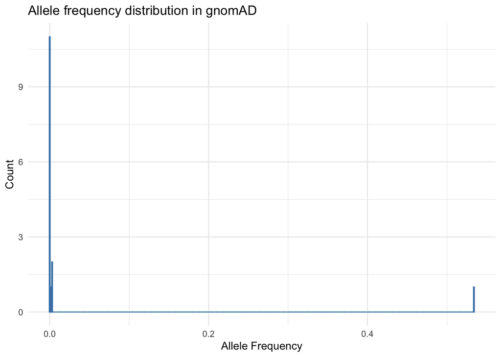

```r
ggplot(annotations, aes(x = af_gnom_ad)) +
  geom_histogram(binwidth = 0.001, fill = "steelblue", color = "steelblue") +
  labs(title = "Allele frequency distribution in gnomAD",
       x = "Allele Frequency", y = "Count") +
  theme_minimal()
```

```r
min(annotations$af_gnom_ad)
```

```
[1] 0
```

```r
max(annotations$af_gnom_ad)
```

```
[1] 0.5341
```

```r
annotations %>%
  filter(af_gnom_ad > 0.1) %>%
  select(gene, genomic_position_chr_pos_ref_alt, clinvar, af_gnom_ad)
```

```
# A tibble: 1 × 4
  gene  genomic_position_chr_pos_ref_alt clinvar       af_gnom_ad
  <chr> <chr>                            <chr>              <dbl>
1 SCN1A 2-166053034-C-T                  drug response      0.534
```

## 4.3 Clinvar and looking at unique values from a categorical/text column.

Periodically, a cell will include multiple values that we want to simplify with a logical operation. For example, the ClinVar column in this table includes multiple assertions that are concatenated together without being meaningfully different for analysis purposes.

```r
# Look at your data and review unique values in the clinvar column
unique(annotations$clinvar)
```

```
[1] "Likely pathogenic"
[2] "Pathogenic/Likely pathogenic, Pathogenic, Likely pathogenic,"
[3] "Benign"
[4] "Conflicting classifications of pathogenicity"
[5] "drug response"
[6] "Uncertain significance"
[7] "Pathogenic"
```

If there is a value that stands out, we might want to look where it is in the table so we can investigate and handle it properly

```r
annotations %>%
  filter(str_detect(clinvar, "Conflicting")) %>%
  select(gene, genomic_position_chr_pos_ref_alt, clinvar)
```

```
# A tibble: 1 × 3
  gene  genomic_position_chr_pos_ref_alt clinvar
  <chr> <chr>                            <chr>
1 G6PD  X-154532247-G-A                  Conflicting classifications of pathoge…
```

We can consolidate some of these into simplified categories tomake our lives easier and our visualizations more clear.

It may be beneficial to review the evidence on ClinVar before accepting an assertion, and/or to understand what may be meant by “conflicting interpretations of pathogenicity” before performing this step.

Because we will use stringr functions and we want to avoid having the code recognize “Conflicting interpretations of **pathogenic**ity” as ~= “Pathogenic”, we will use the ordered function case_when(). This checks for the condition “Conflicting” before “Pathogenic” to ensure only one simplified value is retained for each variant. We also want to ignore variable capitalization.

```r
annotations <- annotations %>%
  mutate(clinvar_simple = case_when(
    str_detect(clinvar, regex("Conflicting", ignore_case = TRUE)) ~ "Conflicting",
    str_detect(clinvar, regex("Pathogenic", ignore_case = TRUE)) ~ "PLP",
    str_detect(clinvar, regex("Benign", ignore_case = TRUE)) ~ "BLB",
    str_detect(clinvar, regex("Uncertain", ignore_case = TRUE)) ~ "VUS",
    TRUE ~ NA_character_
  ))

annotations %>%
  group_by(clinvar_simple, clinvar) %>%
  summarize(n = n_distinct(genomic_position_chr_pos_ref_alt))
```

```
`summarise()` has regrouped the output.
ℹ Summaries were computed grouped by clinvar_simple and clinvar.
ℹ Output is grouped by clinvar_simple.
ℹ Use `summarise(.groups = "drop_last")` to silence this message.
ℹ Use `summarise(.by = c(clinvar_simple, clinvar))` for per-operation grouping
  (`?dplyr::dplyr_by`) instead.
```

```
# A tibble: 7 × 3
# Groups:   clinvar_simple [5]
  clinvar_simple clinvar                                                       n
  <chr>          <chr>                                                     <int>
1 BLB            Benign                                                        2
2 Conflicting    Conflicting classifications of pathogenicity                  1
3 PLP            Likely pathogenic                                             2
4 PLP            Pathogenic                                                    6
5 PLP            Pathogenic/Likely pathogenic, Pathogenic, Likely pathoge…     1
6 VUS            Uncertain significance                                        3
7 <NA>           drug response                                                 1
```

## 4.4 Bioinformatics predictions, reviewing distributions and checking missingness when missingness is not random

There are several nuances to the values in the bioinformatics predictions. Certain variant types are not scored by certain algorithms and thus have NA values that are expected and appropriate. For example, AlphaMissense and REVEL only provides scores for missense variants. We want to be sure to recognize these as appropriately missing based on the variant type, rather than as errors or as zero values. We do not want to set dummy or placeholder values.

We can also notice that there are a few rows where isoform-specific scores are provided with an “&” delimiter. We will take the maximum score across isoforms to get a single value for each variant, but other approaches could be taken depending on the goals of the analysis.

### 4.4.1 Look at the data before you touch it

We can see below that the SpliceAI scores are mostly near zero with a few higher. Meanwhile, the AlphaMissense and REVEL scores span the 0-1 range. With only a few variants, we can’t actually determine if these are bimodal (either near zero or one), uniform (every value equally represented), normally distributed around 0.5 with tails of low and high scores, or something else - but we would want to use that information to select appropriate thresholds for filtering if we were not going to use literature recommendations.

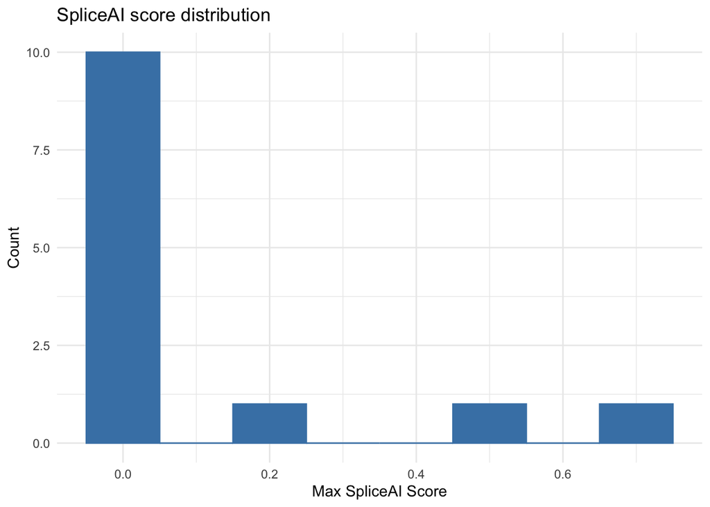

```r
# First, we'll look just at what happens if we plot the raw values that are coercible to numeric without additional parsing.
ggplot(annotations %>% mutate(splice_ai = as.numeric(splice_ai)), aes(x = splice_ai)) +
  geom_histogram(binwidth = 0.1, fill = "steelblue", color = "steelblue") +
  labs(title = "SpliceAI score distribution",
       x = "Max SpliceAI Score", y = "Count") +
  theme_minimal()
```

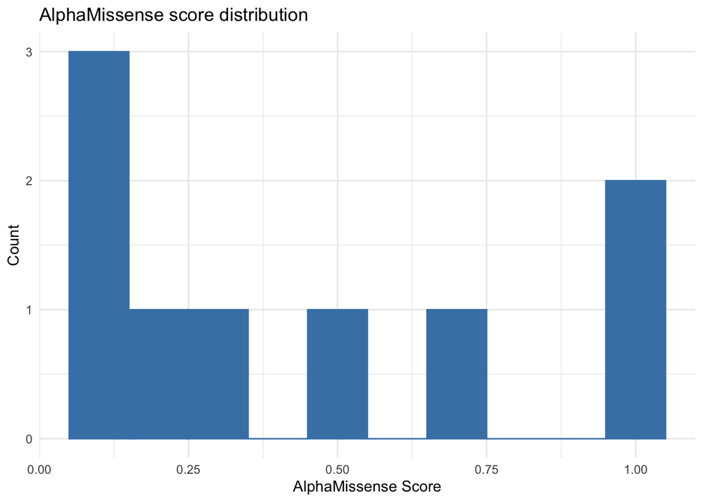

```r
# Do the same for AlphaMissense scores.
ggplot(annotations %>% mutate(alpha_missense_score = as.numeric(alpha_missense_score)), aes(x = alpha_missense_score)) +
  geom_histogram(binwidth = 0.1, fill = "steelblue", color = "steelblue") +
  labs(title = "AlphaMissense score distribution",
       x = "AlphaMissense Score", y = "Count") +
  theme_minimal()
```

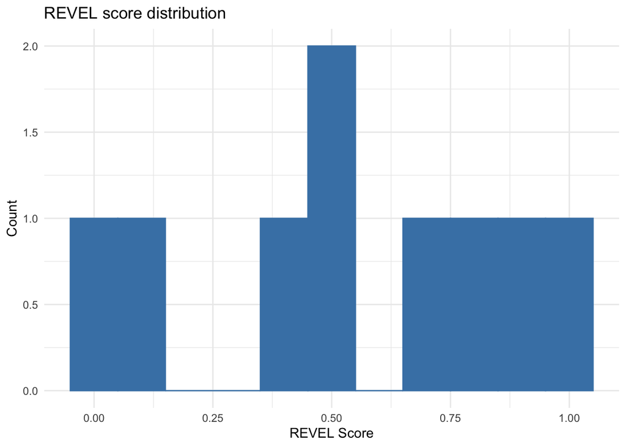

```r
# Repeat for REVEL scores
ggplot(annotations %>% mutate(revel = as.numeric(revel)), aes(x = revel)) +
  geom_histogram(binwidth = 0.1, fill = "steelblue", color = "steelblue") +
  labs(title = "REVEL score distribution",
       x = "REVEL Score", y = "Count") +
  theme_minimal()
```

If you have expectations of these data, check it.

We might reasonably expect that AlphaMissense and REVEL scores (both missense variant predictors) should be correlated. Let’s take a look. Our dataset is a bit too small to do this well, but a correlation does appear to be present.

```
Warning: There were 2 warnings in `mutate()`.
The first warning was:
ℹ In argument: `alpha_missense_score = as.numeric(alpha_missense_score)`.
Caused by warning:
! NAs introduced by coercion
ℹ Run `dplyr::last_dplyr_warnings()` to see the 1 remaining warning.
```

```
Warning: Removed 8 rows containing missing values or values outside the scale range
(`geom_point()`).
```

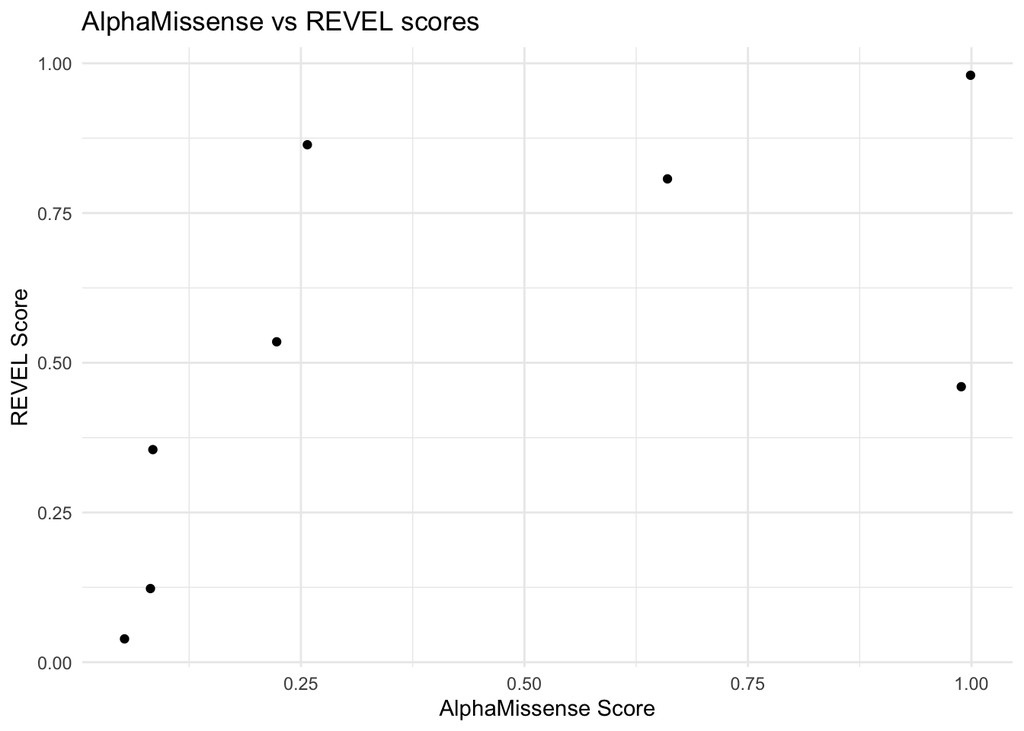

```r
ggplot(annotations %>% mutate(alpha_missense_score = as.numeric(alpha_missense_score), revel = as.numeric(revel)), aes(x = alpha_missense_score, y = revel)) +
  geom_point() +
  labs(title = "AlphaMissense vs REVEL scores",
       x = "AlphaMissense Score", y = "REVEL Score") +
  theme_minimal()
```

### 4.4.2 Evaluate dropouts and preprocess the scores

In the script and figures above we had warnings about missing values or non-finite values in the dataset. This suggests some of the scores are incomplete or have a non-blank value that is still not being recognized as a plot-able numeric value.

When doing complex parsing like this, it may be preferable to create a new object rather than overwriting the existing object. This allows you to make more mistakes and compare the actual outcome with your intention.

```r
annotations_processed <- annotations %>%
  mutate(
    splice_ai = case_when(
      str_detect(splice_ai, "&") ~ str_split(splice_ai, "&") %>% map_dbl(~ max(as.numeric(.x), na.rm = TRUE)),
      TRUE ~ as.numeric(splice_ai)
    ),
    alpha_missense_score = case_when(
      str_detect(alpha_missense_score, "&") ~ str_split(alpha_missense_score, "&") %>% map_dbl(~ max(as.numeric(.x), na.rm = TRUE)),
      TRUE ~ as.numeric(alpha_missense_score)
    ),
    revel = case_when(
      str_detect(revel, "&") ~ str_split(revel, "&") %>% map_dbl(~ max(as.numeric(.x), na.rm = TRUE)),
      TRUE ~ as.numeric(revel)
    )
  )
```

```
Warning: There were 26 warnings in `mutate()`.
The first warning was:
ℹ In argument: `splice_ai = case_when(...)`.
Caused by warning in `max()`:
! no non-missing arguments to max; returning -Inf
ℹ Run `dplyr::last_dplyr_warnings()` to see the 25 remaining warnings.
```

```r
# We can notice that the REVEL score derived from .&. is -INF instead of NA. This makes sense, because there is no mathematical maximum between . and ., however we want to clean up our table and make that an NA for consistency. The pale -INF is a special value, not a character that reads "-INF", so we use a function appropriate for this.
annotations_processed <- annotations_processed %>%
  mutate(revel = if_else(is.infinite(revel), NA_real_, revel))
```

Re-plot the cleaned up scores to see the difference, and review the more reliable result.

### 4.4.3 Look at the clean, analysis-ready data

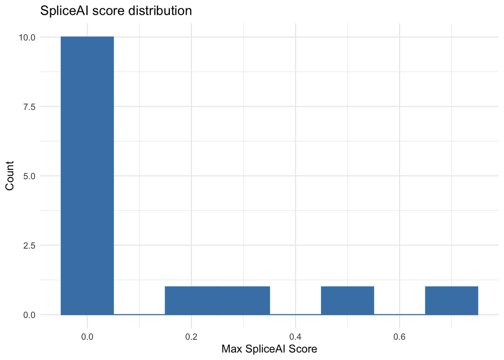

```r
# Replot the same distributions as above, post-processed
ggplot(annotations_processed %>% mutate(splice_ai = as.numeric(splice_ai)), aes(x = splice_ai)) +
  geom_histogram(binwidth = 0.1, fill = "steelblue", color = "steelblue") +
  labs(title = "SpliceAI score distribution",
       x = "Max SpliceAI Score", y = "Count") +
  theme_minimal()
```

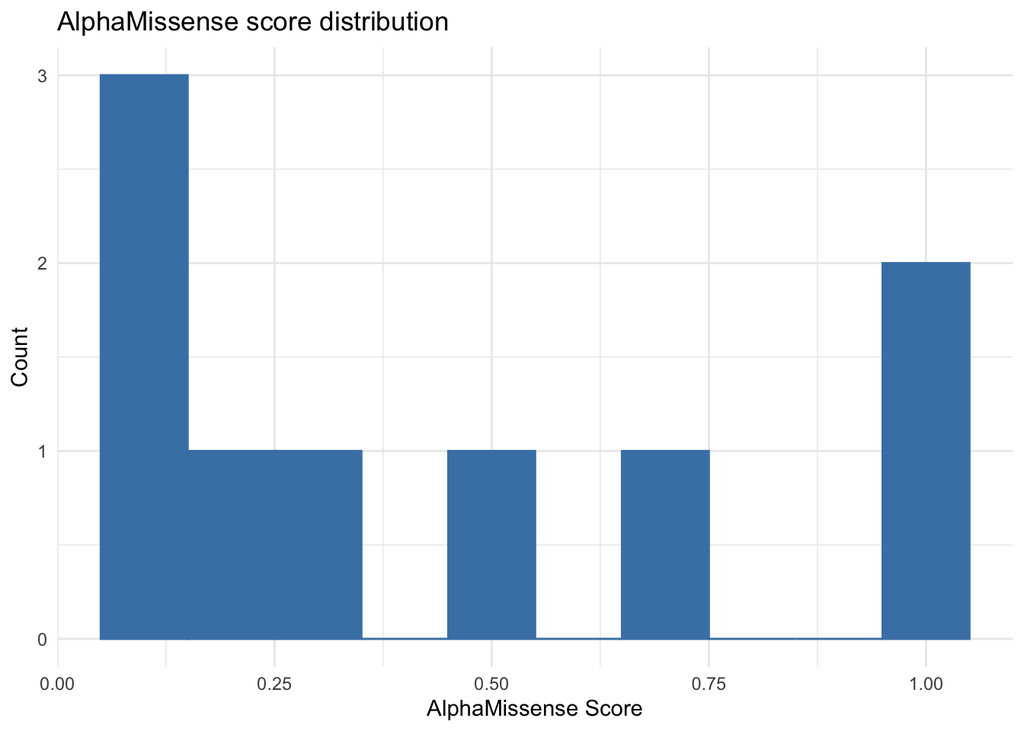

```r
# Do the same for AlphaMissense scores.
ggplot(annotations_processed %>% mutate(alpha_missense_score = as.numeric(alpha_missense_score)), aes(x = alpha_missense_score)) +
  geom_histogram(binwidth = 0.1, fill = "steelblue", color = "steelblue") +
  labs(title = "AlphaMissense score distribution",
       x = "AlphaMissense Score", y = "Count") +
  theme_minimal()
```

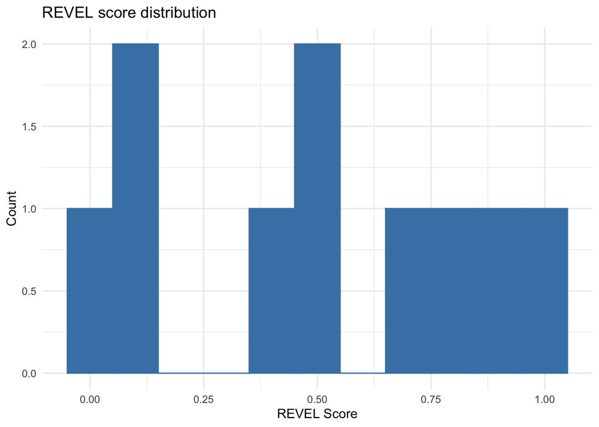

```r
# Repeat for REVEL scores
ggplot(annotations_processed %>% mutate(revel = as.numeric(revel)), aes(x = revel)) +
  geom_histogram(binwidth = 0.1, fill = "steelblue", color = "steelblue") +
  labs(title = "REVEL score distribution",
       x = "REVEL Score", y = "Count") +
  theme_minimal()
```

With tidyier data, we can also check additional hypotheses, like whether pathogenic variants have higher (or lower) average scores.

```r
# This requires pivoting the data to long format so all three scores share one x-axis. Each row becomes one score observation for one variant.

annotation_scores_long <- annotations_processed %>%
  mutate(
    clinvar_group = case_when(
      clinvar_simple == "PLP" ~ "PLP",
      TRUE ~ "Other"
    ),
    clinvar_group = factor(clinvar_group, levels = c("PLP", "Other"))
  ) %>%
  select(clinvar_group, splice_ai, alpha_missense_score, revel) |>
  pivot_longer(
    cols      = c(splice_ai, alpha_missense_score, revel),
    names_to  = "algorithm",
    values_to = "score"
  )
```

Data table conversion between wide and long is common and much easier to do computationally than manually.

Review the data arrangement in the long format

```r
head(annotation_scores_long)
```

```
# A tibble: 6 × 3
  clinvar_group algorithm            score
  <fct>         <chr>                <dbl>
1 PLP           splice_ai             0.33
2 PLP           alpha_missense_score NA
3 PLP           revel                 0.71
4 PLP           splice_ai             0.71
5 PLP           alpha_missense_score NA
6 PLP           revel                NA
```

We know some scores are missing in the dataset. We want to count and represent these explicitly in our plot.

```r
# Computed missingness per score x group for caption annotation. This automatically updates text to be used in the figure caption.
annotation_missing_summary <- annotation_scores_long %>%
  group_by(algorithm, clinvar_group) |>
  summarise(
    n_total   = n(),
    n_missing = sum(is.na(score)),
    .groups   = "drop"
  ) %>%
  mutate(label = paste0(algorithm, " / ", clinvar_group,
                        ": ", n_missing, " missing of ", n_total))

caption_text <- paste(
  "Missing values excluded from boxes and points (not imputed).",
  paste(annotation_missing_summary$label, collapse = "\n"),
  sep = "\n"
)
```

Now we prepare the plot.

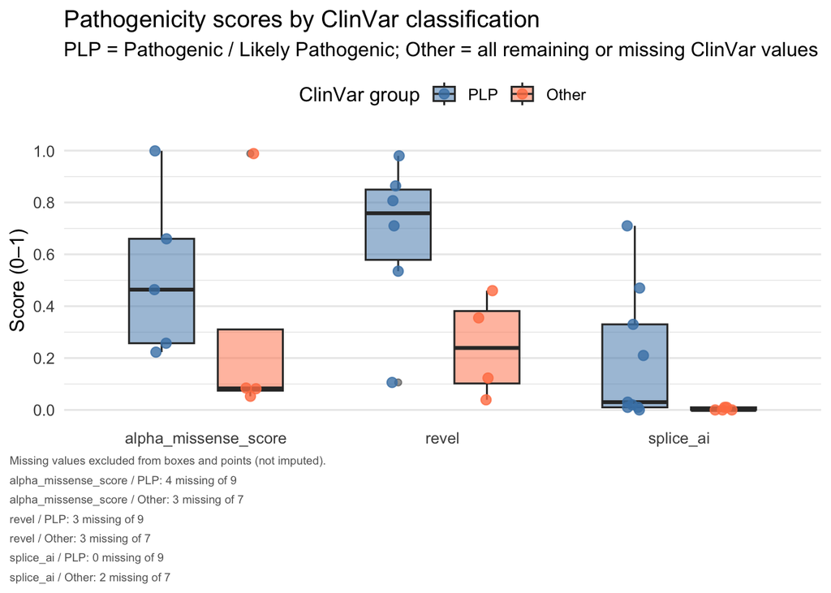

```r
ggplot(annotation_scores_long,
  aes(x = algorithm, y = score, fill = clinvar_group)) +
     geom_boxplot(
      alpha         = 0.5,
      position      = position_dodge(width = 0.75),
      width         = 0.55,
      na.rm         = TRUE
  ) +
    geom_point(
      aes(color = clinvar_group),
      position = position_jitterdodge(
      jitter.width = 0.15,
      dodge.width  = 0.75
    ),
    size  = 2.5,
    alpha = 0.8,
    na.rm = TRUE
  ) +
  scale_fill_manual(
    values = c("PLP" = "steelblue", "Other" = "coral"),
    name   = "ClinVar group"
  ) +
  scale_color_manual(
    values = c("PLP" = "steelblue", "Other" = "coral"),
    name   = "ClinVar group"
  ) +
  scale_y_continuous(limits = c(0, 1), breaks = seq(0, 1, 0.2)) +

  labs(
    title    = "Pathogenicity scores by ClinVar classification",
    subtitle = "PLP = Pathogenic / Likely Pathogenic; Other = all remaining or missing ClinVar values",
    x        = NULL,
    y        = "Score (0\u20131)",
    caption  = caption_text
  ) +

  theme_minimal(base_size = 12) +
  theme(
    legend.position  = "top",
    plot.caption     = element_text(size = 7, color = "grey40",
                                    hjust = 0, lineheight = 1.4),
    plot.caption.position = "plot",
    panel.grid.major.x    = element_blank()
  )
```

# 5. Bring data together

Combining data tables is a common and very straightforward process when you are working computationally.

If two tables have a common ID variable, you can use that directly. If the two tables have a variable representing a common ID but with different column names, or slightly different formatting, you can do some quick parsing to get those into alignment and then join.

## 5.1 Join annotations to variants

Review the input data for basics before joining

```r
# How many unique variants in the variants table?
n_distinct(variants$genomic_position)
```

```
[1] 16
```

```r
# How many unique variants in the annotations table?
n_distinct(annotations_processed$genomic_position_chr_pos_ref_alt)
```

```
[1] 16
```

Check overlap between the two tables. Both seem to have 16 variants, but are they the same 16?

```r
# How many variants are shared between the two tables based on the genomic position? This is a test query; not yet the join.
variants %>%
  inner_join(annotations_processed, by = c("genomic_position" = "genomic_position_chr_pos_ref_alt")) %>%
  nrow()
```

```
[1] 0
```

```r
# We can see that this error is due to differently representing the same variant across the two tables: with or without a "chr" prefix.We can simply paste the "chr" prefix to the chrom column in the annotations table so they should match up.
annotations_processed <- annotations_processed %>%
  mutate(genomic_position = paste0("chr", genomic_position_chr_pos_ref_alt))

variants %>%
  inner_join(annotations_processed, by = c("genomic_position" = "genomic_position")) %>%
  nrow()
```

```
[1] 15
```

```r
# Alternatively, we can review this with a Venn diagram.
table_variants_list <- list(
  variants = unique(variants$genomic_position),
  annotations = unique(annotations_processed$genomic_position)
)
```

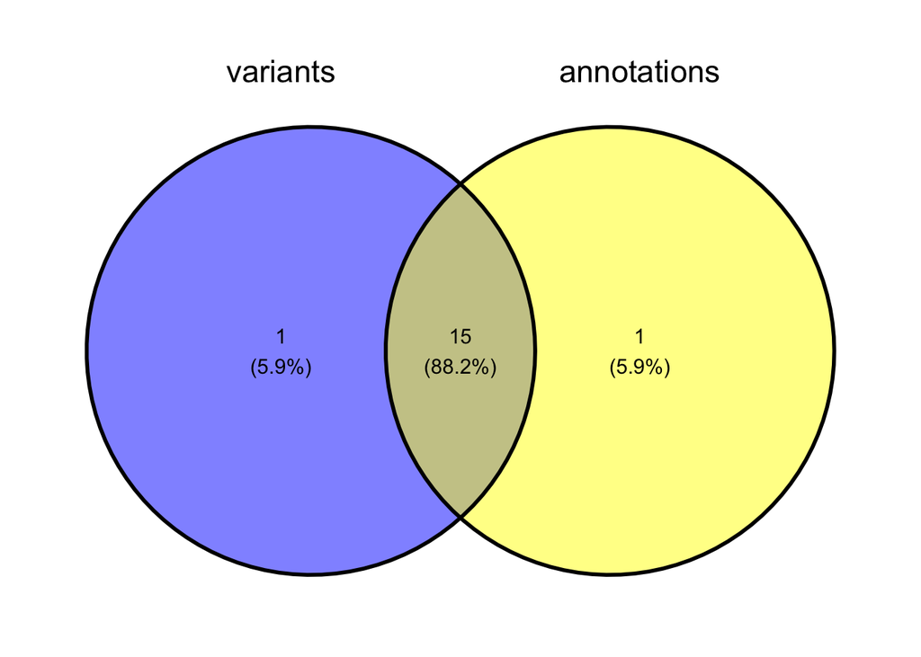

```r
ggvenn(table_variants_list,
  show_elements = FALSE)
```

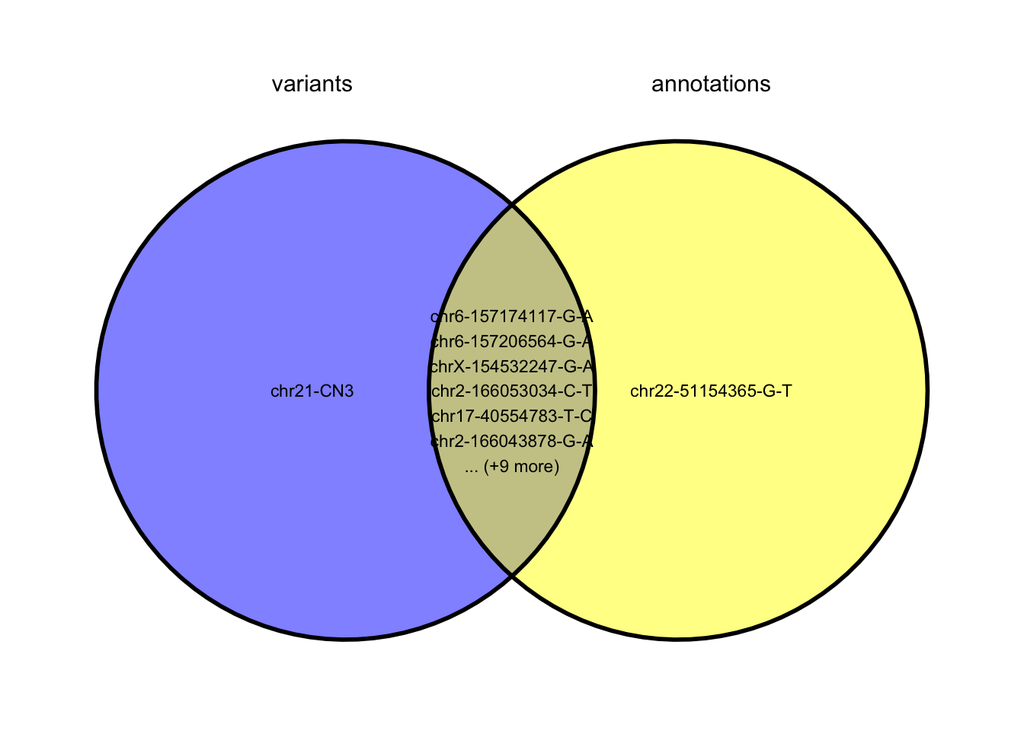

```r
# We can show the element labels in a Venn diagram.
ggvenn(table_variants_list,
  show_elements = TRUE,
  label_sep = "\n",
  set_name_size = 4,
  text_size = 3)
```

We can see that there is one mysterious variant in the annotations table that is not in the variants table.